# Food Service Workers

Aaron Kessler

3/18/2020

*Data source: BLS Occupational Employment Statistics (2018)* *https://www.bls.gov/oes/tables.htm*

## Filtering to just food prep and server worker occupations

A description of whom this category includes: https://www.bls.gov/oes/current/oes350000.htm

Check to see if any our missing or redacted

| area | st | state | occ_code | occ_title | occ_group | tot_emp | jobs_1000 | h_mean | a_mean | share_of_workforce |
| --- | --- | --- | --- | --- | --- | --- | --- | --- | --- | --- |
| 01 | AL | Alabama | 35-2019 | Cooks, All Other | detailed | NA | NA | 15.16 | 31540 | NA |
| 05 | AR | Arkansas | 35-9099 | Food Preparation and Serving Related Workers, All Other | detailed | NA | NA | 10.01 | 20810 | NA |
| 08 | CO | Colorado | 35-1011 | Chefs and Head Cooks | detailed | NA | NA | 24.51 | 50980 | NA |
| 11 | DC | District of Columbia | 35-2019 | Cooks, All Other | detailed | NA | NA | 16.37 | 34060 | NA |
| 11 | DC | District of Columbia | 35-9099 | Food Preparation and Serving Related Workers, All Other | detailed | NA | NA | 18.87 | 39250 | NA |
| 30 | MT | Montana | 35-2015 | Cooks, Short Order | detailed | NA | NA | 12.03 | 25010 | NA |
| 36 | NY | New York | 35-2019 | Cooks, All Other | detailed | NA | NA | 15.77 | 32800 | NA |
| 49 | UT | Utah | 35-9099 | Food Preparation and Serving Related Workers, All Other | detailed | NA | NA | 10.64 | 22140 | NA |
| 50 | VT | Vermont | 35-2011 | Cooks, Fast Food | detailed | NA | NA | 12.34 | 25660 | NA |
| 54 | WV | West Virginia | 35-9099 | Food Preparation and Serving Related Workers, All Other | detailed | NA | NA | 11.26 | 23430 | NA |
| 55 | WI | Wisconsin | 35-2019 | Cooks, All Other | detailed | NA | NA | 11.03 | 22950 | NA |

Just a handful. No worries then, we can work with that.

Do individually listed items add up to the total major? Look at a grand totals and then a few individual states to see.

| occ_group | sum(tot_emp, na.rm = TRUE) |
| --- | --- |
| detailed | 13367380 |
| major | 13374600 |

| occ_group | sum(tot_emp, na.rm = TRUE) |
| --- | --- |
| detailed | 307530 |
| major | 307540 |

| occ_group | sum(tot_emp, na.rm = TRUE) |
| --- | --- |
| detailed | 1594580 |
| major | 1594570 |

| occ_group | sum(tot_emp, na.rm = TRUE) |
| --- | --- |
| detailed | 264460 |
| major | 264450 |

This is pretty close! There could be some NAs among the detailed categories which could increase the spread for certain states, but this appears to be what’s going on.

### States by overall totals

To keep things simple to start, we’ll just look at the overarching total from the major category record for each state.

Total people employed overall.  
Let’s double-check check to make sure we know what kind of workers are included here and who isn’t…if there are any known quirks to be aware of.

| sum(tot_emp) |
| --- |
| 13374600 |

Which states have the highest rate of employment in this sector per 1000?

| area | st | state | occ_code | tot_emp | jobs_1000 | a_mean | share_of_workforce |
| --- | --- | --- | --- | --- | --- | --- | --- |
| 32 | NV | Nevada | 35-0000 | 188280 | 139.764 | 26880 | 13.9764 |
| 15 | HI | Hawaii | 35-0000 | 85770 | 133.634 | 37320 | 13.3634 |
| 30 | MT | Montana | 35-0000 | 51120 | 110.353 | 23550 | 11.0353 |
| 12 | FL | Florida | 35-0000 | 933780 | 108.47 | 25470 | 10.847 |
| 35 | NM | New Mexico | 35-0000 | 83420 | 102.777 | 22060 | 10.2777 |
| 44 | RI | Rhode Island | 35-0000 | 49510 | 102.717 | 28260 | 10.2717 |
| 45 | SC | South Carolina | 35-0000 | 209530 | 101.602 | 21910 | 10.1602 |
| 40 | OK | Oklahoma | 35-0000 | 158940 | 99.69 | 21450 | 9.969 |
| 46 | SD | South Dakota | 35-0000 | 41760 | 98.884 | 23210 | 9.8884 |
| 22 | LA | Louisiana | 35-0000 | 188490 | 98.491 | 20980 | 9.8491 |

[output cut: 41 more lines]

This is interesting…as some of the states with the lowest populations actually have the highest percentage of people in this industry.

What’s the range in values?

| minvalue | maxvalue |
| --- | --- |
| 75.933 | 139.764 |

### Metropolitan area totals

Let’s look at the same thing, the grand totals for all the food prep/service workers - but this time pulling from the Metro area (MSA) data.

Which metro areas have the highest rate of workers in the industry?

| prim_state | area | area_name | occ_code | tot_emp | jobs_1000 | a_mean | share_of_workforce |
| --- | --- | --- | --- | --- | --- | --- | --- |
| HI | 27980 | Kahului-Wailuku-Lahaina, HI | 35-0000 | 14150 | 187.844 | 43070 | 18.7844 |
| SC | 34820 | Myrtle Beach-Conway-North Myrtle Beach, SC-NC | 35-0000 | 29440 | 180.722 | 22500 | 18.0722 |
| NJ | 36140 | Ocean City, NJ | 35-0000 | 7000 | 179.205 | 28650 | 17.9205 |
| AL | 19300 | Daphne-Fairhope-Foley, AL | 35-0000 | 11770 | 162.439 | 23150 | 16.2439 |
| GA | 15260 | Brunswick, GA | 35-0000 | 6730 | 160.455 | 22040 | 16.0455 |
| SC | 25940 | Hilton Head Island-Bluffton-Beaufort, SC | 35-0000 | 12080 | 159.997 | 23050 | 15.9997 |
| AZ | 22380 | Flagstaff, AZ | 35-0000 | 9850 | 159.093 | 26560 | 15.9093 |
| NC | 27340 | Jacksonville, NC | 35-0000 | 7460 | 158.604 | 20380 | 15.8604 |
| NV | 29820 | Las Vegas-Henderson-Paradise, NV | 35-0000 | 151260 | 153.278 | 27810 | 15.3278 |
| FL | 18880 | Crestview-Fort Walton Beach-Destin, FL | 35-0000 | 16740 | 151.395 | 25670 | 15.1395 |

[output cut: 378 more lines]

Well it looks like my hometown area in South Jersey, near Atlantic City, is number 3. Well that’s wonderful. :(

What’s the range in values for per 1000 figure here so we have a sense of it.

| minvalue | maxvalue |
| --- | --- |
| 55.293 | 187.844 |

That’s a pretty large difference between the worst metros and the best.  
Let’s take a quick look at what the distribution looks like with a historgram.

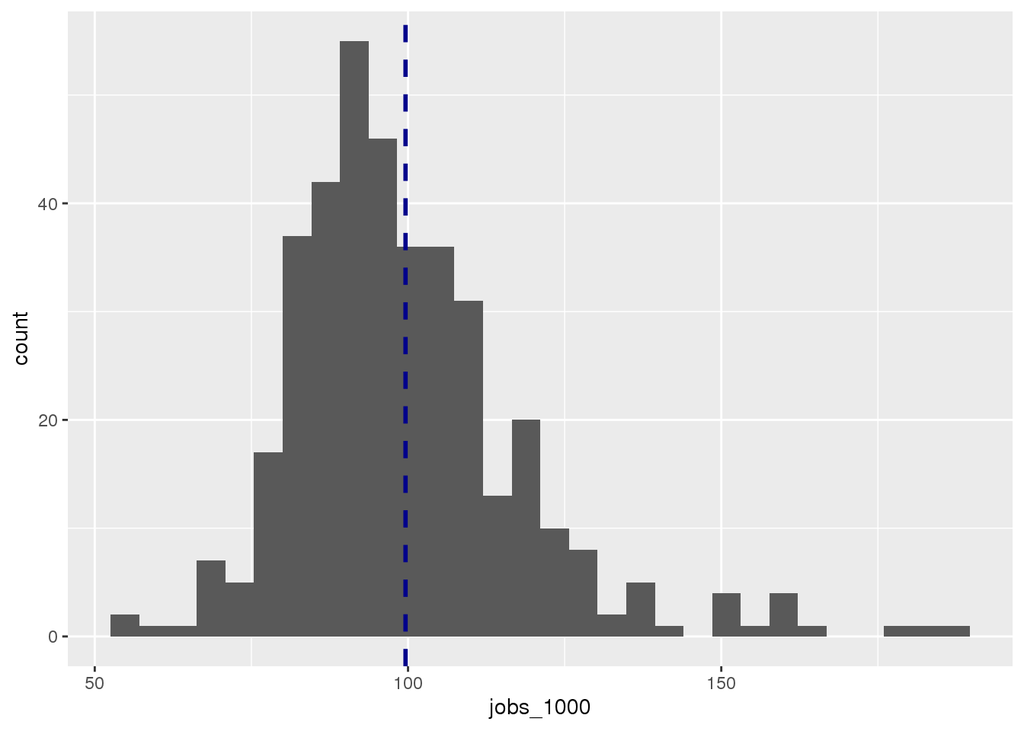

The plot above shows that metro areas all the way to the right - our worst-case metros - really do have an outsized vulnerability compared with the rest of the country. The mean (shown by the blue line above) is about 100 per 1000, or 1 out of every 10 workers.

### Combined Food Preparation and Serving Workers, Including Fast Food

A more specific group within the larger sector, let’s take a look. (Need to investiate just what this does and doesn’t include a bit more, but including here for now.)

By state:

| area | st | state | occ_code | occ_title | tot_emp | jobs_1000 | a_mean | share_of_workforce |
| --- | --- | --- | --- | --- | --- | --- | --- | --- |
| 45 | SC | South Carolina | 35-3021 | Combined Food Preparation and Serving Workers, Including Fast Food | 71480 | 34.662 | 18910 | 3.4662 |
| 21 | KY | Kentucky | 35-3021 | Combined Food Preparation and Serving Workers, Including Fast Food | 65410 | 34.608 | 19150 | 3.4608 |
| 37 | NC | North Carolina | 35-3021 | Combined Food Preparation and Serving Workers, Including Fast Food | 147170 | 33.576 | 19730 | 3.3576 |
| 48 | TX | Texas | 35-3021 | Combined Food Preparation and Serving Workers, Including Fast Food | 389740 | 32.173 | 20880 | 3.2173 |
| 01 | AL | Alabama | 35-3021 | Combined Food Preparation and Serving Workers, Including Fast Food | 62030 | 31.914 | 18680 | 3.1914 |
| 05 | AR | Arkansas | 35-3021 | Combined Food Preparation and Serving Workers, Including Fast Food | 38540 | 31.851 | 19960 | 3.1851 |
| 54 | WV | West Virginia | 35-3021 | Combined Food Preparation and Serving Workers, Including Fast Food | 21890 | 31.421 | 20600 | 3.1421 |
| 18 | IN | Indiana | 35-3021 | Combined Food Preparation and Serving Workers, Including Fast Food | 94470 | 30.994 | 19570 | 3.0994 |
| 13 | GA | Georgia | 35-3021 | Combined Food Preparation and Serving Workers, Including Fast Food | 136200 | 30.992 | 19180 | 3.0992 |
| 49 | UT | Utah | 35-3021 | Combined Food Preparation and Serving Workers, Including Fast Food | 43840 | 30.11 | 20440 | 3.011 |

[output cut: 41 more lines]

By metro area:

| prim_state | area | area_name | occ_code | occ_title | tot_emp | jobs_1000 | a_mean | share_of_workforce |
| --- | --- | --- | --- | --- | --- | --- | --- | --- |
| NC | 27340 | Jacksonville, NC | 35-3021 | Combined Food Preparation and Serving Workers, Including Fast Food | 3540 | 75.299 | 18780 | 7.5299 |
| GA | 25980 | Hinesville, GA | 35-3021 | Combined Food Preparation and Serving Workers, Including Fast Food | 1110 | 61.708 | 18260 | 6.1708 |
| SC | 22500 | Florence, SC | 35-3021 | Combined Food Preparation and Serving Workers, Including Fast Food | 4490 | 51.924 | 18550 | 5.1924 |
| NC | 15500 | Burlington, NC | 35-3021 | Combined Food Preparation and Serving Workers, Including Fast Food | 3130 | 51.235 | 19210 | 5.1235 |
| NC | 22180 | Fayetteville, NC | 35-3021 | Combined Food Preparation and Serving Workers, Including Fast Food | 6450 | 49.994 | 20110 | 4.9994 |
| MI | 13020 | Bay City, MI | 35-3021 | Combined Food Preparation and Serving Workers, Including Fast Food | 1660 | 49.89 | 22270 | 4.989 |
| AL | 11500 | Anniston-Oxford-Jacksonville, AL | 35-3021 | Combined Food Preparation and Serving Workers, Including Fast Food | 2170 | 49.515 | 19020 | 4.9515 |
| TX | 43300 | Sherman-Denison, TX | 35-3021 | Combined Food Preparation and Serving Workers, Including Fast Food | 2220 | 49.357 | 20490 | 4.9357 |
| GA | 15260 | Brunswick, GA | 35-3021 | Combined Food Preparation and Serving Workers, Including Fast Food | 2050 | 48.944 | 19400 | 4.8944 |
| MI | 34740 | Muskegon, MI | 35-3021 | Combined Food Preparation and Serving Workers, Including Fast Food | 3060 | 47.986 | 21830 | 4.7986 |

[output cut: 378 more lines]

# Slicing out a specific type of worker

### Waiters/Waitresses

Clearly wait staff is going to be hit hard even if some establishments stay open for take-out and delivery. They won’t need servers for that, so they’re likely to still lose out.

Let’s look at just wait staff at the state level

| area | st | state | occ_code | occ_title | tot_emp | jobs_1000 | a_mean | share_of_workforce |
| --- | --- | --- | --- | --- | --- | --- | --- | --- |
| 15 | HI | Hawaii | 35-3031 | Waiters and Waitresses | 19130 | 29.813 | 52110 | 2.9813 |
| 32 | NV | Nevada | 35-3031 | Waiters and Waitresses | 37400 | 27.762 | 24980 | 2.7762 |
| 12 | FL | Florida | 35-3031 | Waiters and Waitresses | 211860 | 24.611 | 26120 | 2.4611 |
| 30 | MT | Montana | 35-3031 | Waiters and Waitresses | 10260 | 22.153 | 20990 | 2.2153 |
| 23 | ME | Maine | 35-3031 | Waiters and Waitresses | 12890 | 21.287 | 27550 | 2.1287 |
| 44 | RI | Rhode Island | 35-3031 | Waiters and Waitresses | 9950 | 20.633 | 27380 | 2.0633 |
| 35 | NM | New Mexico | 35-3031 | Waiters and Waitresses | 16730 | 20.606 | 20770 | 2.0606 |
| 22 | LA | Louisiana | 35-3031 | Waiters and Waitresses | 38950 | 20.352 | 18630 | 2.0352 |
| 08 | CO | Colorado | 35-3031 | Waiters and Waitresses | 50390 | 19.229 | 25510 | 1.9229 |
| 33 | NH | New Hampshire | 35-3031 | Waiters and Waitresses | 12510 | 19.165 | 24850 | 1.9165 |

[output cut: 41 more lines]

And the metro area level…

| prim_state | area | area_name | occ_code | occ_title | tot_emp | jobs_1000 | a_mean | share_of_workforce |
| --- | --- | --- | --- | --- | --- | --- | --- | --- |
| HI | 27980 | Kahului-Wailuku-Lahaina, HI | 35-3031 | Waiters and Waitresses | 4130 | 54.807 | 52080 | 5.4807 |
| FL | 45540 | The Villages, FL | 35-3031 | Waiters and Waitresses | 1420 | 51.992 | 22000 | 5.1992 |
| SC | 34820 | Myrtle Beach-Conway-North Myrtle Beach, SC-NC | 35-3031 | Waiters and Waitresses | 7740 | 47.486 | 21320 | 4.7486 |
| NJ | 36140 | Ocean City, NJ | 35-3031 | Waiters and Waitresses | 1760 | 45.101 | 28730 | 4.5101 |
| FL | 18880 | Crestview-Fort Walton Beach-Destin, FL | 35-3031 | Waiters and Waitresses | 4490 | 40.594 | 25750 | 4.0594 |
| SC | 25940 | Hilton Head Island-Bluffton-Beaufort, SC | 35-3031 | Waiters and Waitresses | 3000 | 39.791 | 19930 | 3.9791 |
| FL | 37460 | Panama City, FL | 35-3031 | Waiters and Waitresses | 3220 | 39.136 | 22810 | 3.9136 |
| FL | 34940 | Naples-Immokalee-Marco Island, FL | 35-3031 | Waiters and Waitresses | 5640 | 38.635 | 33650 | 3.8635 |
| NJ | 12100 | Atlantic City-Hammonton, NJ | 35-3031 | Waiters and Waitresses | 4540 | 36.127 | 24910 | 3.6127 |
| AZ | 22380 | Flagstaff, AZ | 35-3031 | Waiters and Waitresses | 2180 | 35.281 | 27400 | 3.5281 |

[output cut: 378 more lines]

Well that’s not good again for South Jersey. Both Ocean City and Atlantic City both listed here.

### Dishwashers

By state:

| area | st | state | occ_code | occ_title | tot_emp | jobs_1000 | a_mean | share_of_workforce |
| --- | --- | --- | --- | --- | --- | --- | --- | --- |
| 15 | HI | Hawaii | 35-9021 | Dishwashers | 4480 | 6.975 | 28370 | 0.6975 |
| 32 | NV | Nevada | 35-9021 | Dishwashers | 9390 | 6.967 | 26980 | 0.6967 |
| 11 | DC | District of Columbia | 35-9021 | Dishwashers | 4190 | 5.883 | 31310 | 0.5883 |
| 44 | RI | Rhode Island | 35-9021 | Dishwashers | 2680 | 5.564 | 25290 | 0.5564 |
| 30 | MT | Montana | 35-9021 | Dishwashers | 2260 | 4.884 | 21370 | 0.4884 |
| 06 | CA | California | 35-9021 | Dishwashers | 81580 | 4.797 | 25650 | 0.4797 |
| 46 | SD | South Dakota | 35-9021 | Dishwashers | 1990 | 4.718 | 21340 | 0.4718 |
| 12 | FL | Florida | 35-9021 | Dishwashers | 39250 | 4.56 | 21850 | 0.456 |
| 41 | OR | Oregon | 35-9021 | Dishwashers | 8060 | 4.272 | 25010 | 0.4272 |
| 25 | MA | Massachusetts | 35-9021 | Dishwashers | 15020 | 4.205 | 27730 | 0.4205 |

[output cut: 41 more lines]

By metro area:

| prim_state | area | area_name | occ_code | occ_title | tot_emp | jobs_1000 | a_mean | share_of_workforce |
| --- | --- | --- | --- | --- | --- | --- | --- | --- |
| MA | 70900 | Barnstable Town, MA | 35-9021 | Dishwashers | 1080 | 10.46 | 26110 | 1.046 |
| HI | 27980 | Kahului-Wailuku-Lahaina, HI | 35-9021 | Dishwashers | 730 | 9.672 | 33370 | 0.9672 |
| PA | 20700 | East Stroudsburg, PA | 35-9021 | Dishwashers | 530 | 9.67 | 20480 | 0.967 |
| GA | 15260 | Brunswick, GA | 35-9021 | Dishwashers | 390 | 9.37 | 19510 | 0.937 |
| AZ | 29420 | Lake Havasu City-Kingman, AZ | 35-9021 | Dishwashers | 430 | 8.654 | 24160 | 0.8654 |
| AZ | 22380 | Flagstaff, AZ | 35-9021 | Dishwashers | 530 | 8.576 | 23560 | 0.8576 |
| NV | 29820 | Las Vegas-Henderson-Paradise, NV | 35-9021 | Dishwashers | 7480 | 7.582 | 28500 | 0.7582 |
| NJ | 36140 | Ocean City, NJ | 35-9021 | Dishwashers | 290 | 7.355 | 22430 | 0.7355 |
| SC | 25940 | Hilton Head Island-Bluffton-Beaufort, SC | 35-9021 | Dishwashers | 560 | 7.355 | 23130 | 0.7355 |
| FL | 34940 | Naples-Immokalee-Marco Island, FL | 35-9021 | Dishwashers | 1070 | 7.293 | 23380 | 0.7293 |

[output cut: 371 more lines]

### Bartenders

By state:

| area | st | state | occ_code | occ_title | tot_emp | jobs_1000 | a_mean | share_of_workforce |
| --- | --- | --- | --- | --- | --- | --- | --- | --- |
| 32 | NV | Nevada | 35-3011 | Bartenders | 15050 | 11.169 | 27590 | 1.1169 |
| 30 | MT | Montana | 35-3011 | Bartenders | 4580 | 9.894 | 21570 | 0.9894 |
| 38 | ND | North Dakota | 35-3011 | Bartenders | 4110 | 9.878 | 20880 | 0.9878 |
| 55 | WI | Wisconsin | 35-3011 | Bartenders | 26330 | 9.242 | 22740 | 0.9242 |
| 56 | WY | Wyoming | 35-3011 | Bartenders | 2290 | 8.496 | 22060 | 0.8496 |
| 44 | RI | Rhode Island | 35-3011 | Bartenders | 4040 | 8.372 | 27100 | 0.8372 |
| 46 | SD | South Dakota | 35-3011 | Bartenders | 3360 | 7.957 | 22300 | 0.7957 |
| 11 | DC | District of Columbia | 35-3011 | Bartenders | 5130 | 7.2 | 43600 | 0.72 |
| 50 | VT | Vermont | 35-3011 | Bartenders | 2070 | 6.793 | 36720 | 0.6793 |
| 02 | AK | Alaska | 35-3011 | Bartenders | 2030 | 6.428 | 28180 | 0.6428 |

[output cut: 41 more lines]

By metro area:

| prim_state | area | area_name | occ_code | occ_title | tot_emp | jobs_1000 | a_mean | share_of_workforce |
| --- | --- | --- | --- | --- | --- | --- | --- | --- |
| WI | 29100 | La Crosse-Onalaska, WI-MN | 35-3011 | Bartenders | 1140 | 15.137 | 21000 | 1.5137 |
| NJ | 12100 | Atlantic City-Hammonton, NJ | 35-3011 | Bartenders | 1570 | 12.477 | 29330 | 1.2477 |
| NV | 29820 | Las Vegas-Henderson-Paradise, NV | 35-3011 | Bartenders | 12110 | 12.27 | 29400 | 1.227 |
| PA | 27780 | Johnstown, PA | 35-3011 | Bartenders | 610 | 12.029 | 18700 | 1.2029 |
| NJ | 36140 | Ocean City, NJ | 35-3011 | Bartenders | 460 | 11.779 | 29870 | 1.1779 |
| MI | 13020 | Bay City, MI | 35-3011 | Bartenders | 370 | 11.184 | 19940 | 1.1184 |
| HI | 27980 | Kahului-Wailuku-Lahaina, HI | 35-3011 | Bartenders | 820 | 10.884 | 57310 | 1.0884 |
| MT | 24500 | Great Falls, MT | 35-3011 | Bartenders | 370 | 10.687 | 21840 | 1.0687 |
| WI | 20740 | Eau Claire, WI | 35-3011 | Bartenders | 860 | 10.41 | 22780 | 1.041 |
| MN | 20260 | Duluth, MN-WI | 35-3011 | Bartenders | 1290 | 10.137 | 21420 | 1.0137 |

[output cut: 372 more lines]

# Next up: Earnings power lost

If we multiply the average annual earnings for each occupation by the number of employed people in that profession - both of which the BLS data includes - that should give us an estimated dollar value we can peg to the lost potential earnings we’re talking about.

Let’s give that a try.

To keep things a bit more simple to start, let’s do this with the national figures for all of the United States.

```
## # A tibble: 26 x 7
##    data_scope occ_code occ_title                 occ_group tot_emp h_mean a_mean
##    <chr>      <chr>    <chr>                     <chr>       <dbl>  <dbl>  <dbl>
##  1 national   35-0000  Food Preparation and Ser… major      1.34e7   12.3  25580
##  2 national   35-1000  Supervisors of Food Prep… minor      1.09e6   18.3  38070
##  3 national   35-1011  Chefs and Head Cooks      detailed   1.29e5   25.1  52160
##  4 national   35-1012  First-Line Supervisors o… detailed   9.64e5   17.4  36190
##  5 national   35-2000  Cooks and Food Preparati… minor      3.22e6   12.6  26120
##  6 national   35-2010  Cooks                     broad      2.40e6   12.8  26560
##  7 national   35-2011  Cooks, Fast Food          detailed   4.88e5   10.9  22650
##  8 national   35-2012  Cooks, Institution and C… detailed   4.00e5   13.6  28290
##  9 national   35-2013  Cooks, Private Household  detailed   4.60e2   19.8  41240
## 10 national   35-2014  Cooks, Restaurant         detailed   1.34e6   13.3  27580
## # … with 16 more rows
```

We’ll add the new column for earning power

| occ_title | occ_group | earning_power_dollars | tot_emp |
| --- | --- | --- | --- |
| Food Preparation and Serving Related Occupations | major | 342122779600 | 13374620 |
| Supervisors of Food Preparation and Serving Workers | minor | 41610510000 | 1093000 |
| Chefs and Head Cooks | detailed | 6707776000 | 128600 |
| First-Line Supervisors of Food Preparation and Serving Workers | detailed | 34901636000 | 964400 |
| Cooks and Food Preparation Workers | minor | 84057033200 | 3218110 |
| Cooks | broad | 63837225600 | 2403510 |
| Cooks, Fast Food | detailed | 11042101500 | 487510 |
| Cooks, Institution and Cafeteria | detailed | 11325052800 | 400320 |
| Cooks, Private Household | detailed | 18970400 | 460 |
| Cooks, Restaurant | detailed | 36979539800 | 1340810 |

[output cut: 16 more lines]

So for the entire major cateory here, we’re talking about potentially **$340 BILLION** in annual earning power potentially evaporating if all those people lost their jobs.

Waiters and waitresses alone would be nearly **$67 billion** in earnings lost.

Bartenders would be another **$17 billion**.

Dishwashers would be nearly **$12 billion**.

Hosts and hostesses who work at restaurants, lounges and coffee shops would be nearly **$10 billion**.

# MAPS

#### A few rudimentary maps for the heck of it

Bring in geospatial boundaries of MSA via CBSA tigris download, and states as well

We’ll try joining this to our MSA totals for the industry major category

Map it

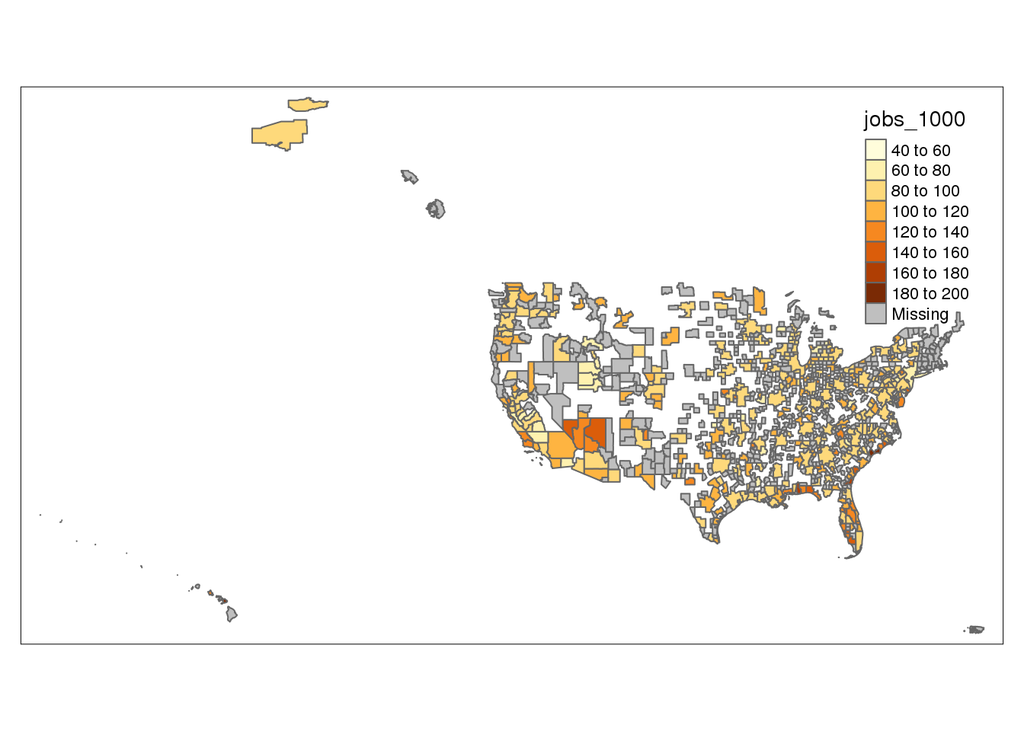

### State map of total industry

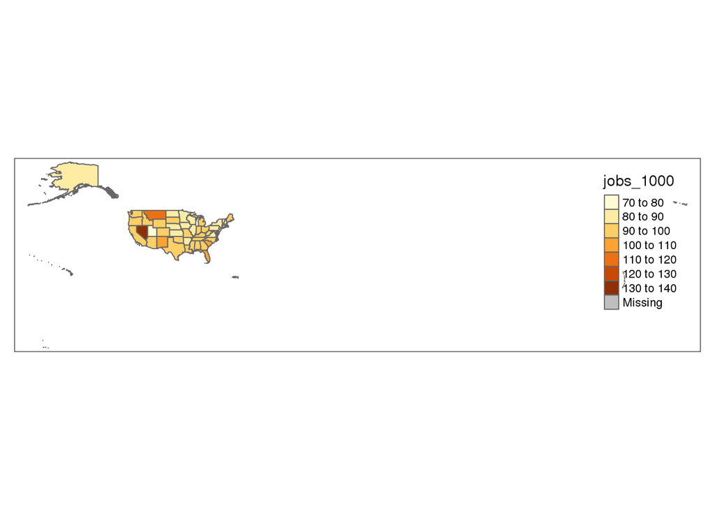